# Exploring the BRFSS data

# Introduction

This document is prepared to fulfill the requirements for Duke’s *Statistics with R* Class hosted by Coursera. A data set is provided for the assignment - Behavioral Risk Factor Surveillance System (BRFSS).

The project consists of 3 parts:

1. **Data**: (3 points) Describe how the observations in the sample are collected, and the implications of this data collection method on the scope of inference (generalizability / causality). Note that you will need to look into documentation on the BRFSS to answer this question. See http://www.cdc.gov/brfss/
2. **Research questions**: (11 points) Come up with at least three research questions that you want to answer using these data. You should phrase your research questions in a way that matches up with the scope of inference your data set allows for. Make sure that at least two of these questions involve at least three variables. You are welcomed to create new variables based on existing ones. With each question include a brief discussion (1-2 sentences) as to why this question is of interest to you and/or your audience.
3. **EDA**: (30 points) Perform exploratory data analysis (EDA) that addresses each of the three research questions you outlined above. Your EDA should contain numerical summaries and visualizations. Each R output and plot should be accompanied by a brief interpretation.

**Note**: 6 points allocated to overall organization and readability of your project. Total points add up to 50 points.

## About BRFSS

The [Behavioral Risk Factor Surveillance System (BRFSS)](http://www.cdc.gov/brfss/annual_data/2013/pdf/Overview_2013.pdf) is a collaborative project between all of the states in the United States (US) and participating US territories and the Centers for Disease Control and Prevention (CDC). The BRFSS was initiated in 1984, with 15 states collecting surveillance data on risk behaviors through monthly telephone interviews. Over time, the number of states participating in the survey increased; by 2001, 50 states, the District of Columbia, Puerto Rico, Guam, and the US Virgin Islands were participating in the BRFSS. Today, all 50 states, the District of Columbia, Puerto Rico, and Guam collect data annually and American Samoa, Federated States of Micronesia, and Palau collect survey data over a limited point- in-time (usually one to three months).

The BRFSS objective is to collect uniform, state-specific data on preventive health practices and risk behaviors that are linked to chronic diseases, injuries, and preventable infectious diseases that affect the adult population.

Sample Description In a telephone survey such as the BRFSS, a sample record is one telephone number in the list of all telephone numbers the system randomly selects for dialing. To meet the BRFSS standard for the participating states’ sample designs, one must be able to justify sample records as a probability sample of all households with telephones in the state. All participating areas met this criterion in 2013. Fifty-one projects used a disproportionate stratified sample (DSS) design for their landline samples. Guam and Puerto Rico used a simple random-sample design.

## BRFSS Data Collection

Tee information below is referenced from the [BRFSS User Guide](http://www.cdc.gov/brfss/data_documentation/pdf/userguidejune2013.pdf) States are responsible to execute the interviewing process. States may opt to contract with a private company or university to conduct interviews or conduct interviews internally, but regardless of who conducts data collection, it is done according to BRFSS protocols. Surveys are conducted using the following procedure:

- Conduct 20% of the interviews on weekdays
- Conduct 80% on weeknights and weekends
- Change schedules to accommodate holidays and special events
- Make weekday calls just after the dinner hour
- Make appointment callbacks during hours that are not scheduled for other interviews, generally on weekdays.

### Interesting Sampling Facts

- Landline interviews are held with eligible households. Cellular telephone respondents are weighed as single adult households.*An eligible household is defined as a housing unit that has a separate entrance, where occupants eat separately from other persons on the property, and that is occupied by its members as their principal or secondary place of residence. The following are non-eligible households: vacation homes not occupied by household members for more than 30 days per year, group homes, institutions, and (in the landline sample) households in states other than the one conducting the particular BRFSS questionnaire. Since 2011, adult students living in college housing were included as eligible respondents.*
- Landlines use a sampling methodology called disproportionate stratified sampling (DSS). DSS draws telephone numbers from two strata based on the presumed density of known telephone household numbers. The strata are defined as either high density or medium density. Telephone numbers from the high density stratum are sampled at a higher rate. The BRFSS User Guide states **DSS sampling telephone numbers is more efficient than simple random sampling.**
- Cellular phone participants are randomly selected with each having equal probability of selection.
- BRFSS recommends at least 4,000 interviews per state per year.
- BRFSS uses a weighting process as an important statistical tool that attempts to remove bias in the sample. The weighting protocols ensure the data are representative of the population on the following demographics:
- sex
- age
- race
- education
- marital status
- home ownership
- phone ownership
- region

## Get Data

Let’s first get the data. Duke made it pretty easy - it is really an RData file so we can just load it into the project directly. I first set my working directory and then load the data.

```r
setwd("~/GitHub/IntroToProbability/project")#set the working directory
if(!exists("brfss2013")) load("./data/brfss2013.RData")#only load the data if it is not already loaded
```

Some [important notes](http://www.cdc.gov/brfss/annual_data/2013/pdf/CODEBOOK13_LLCP.pdf) about the data:

- All missing values are coded NA in the R Workspace.
- Many variables, such as age, race, education, as well as variables that measure counts of events (drinks, times eating fruit, etc.) have alternate versions in the Calculated Variables section of the data set. Review this section prior to choosing variables for analysis.

Let’s get only the data we need. I know I want to look at data between the US States and the US Territories.

The BRFSS was initiated in 1984, with 15 states collecting surveillance data on risk behaviors through monthly telephone interviews. Over time, the number of states participating in the survey increased; by 2001, 50 states, the District of Columbia, Puerto Rico, Guam, and the US Virgin Islands were participating in the BRFSS. Today, all 50 states, the District of Columbia, **Puerto Rico**, and **Guam** collect data annually and American Samoa, Federated States of Micronesia, and Palau collect survey data over a limited point- in-time (usually one to three months).

Let’s add a new column to the data (like we more than the 330 we already have) to identify if the observation is from a US State, i.e., not either Puerto Rico or Guam. This will take a few steps to complete:

Let’s check the state data first to make sure it is clean and tidy.

```r
#Before assigning a new column for US State v Not US State, let's make sure the state data looks clean:
unique(brfss2013$X_state)
```

```
##  [1] Alabama              Alaska               Arizona
##  [4] Arkansas             California           Colorado
##  [7] Connecticut          Delaware             District of Columbia
## [10] Florida              80                   Georgia
## [13] Hawaii               Idaho                Illinois
## [16] Indiana              Iowa                 Kansas
## [19] Kentucky             Louisiana            Maine
## [22] Maryland             Massachusetts        Michigan
## [25] 0                    Minnesota            Mississippi
## [28] Missouri             Montana              Nebraska
## [31] Nevada               New Hampshire        New Jersey
## [34] New Mexico           New York             North Carolina
## [37] North Dakota         Ohio                 Oklahoma
## [40] Oregon               Pennsylvania         Rhode Island
## [43] South Carolina       South Dakota         Tennessee
## [46] Texas                Utah                 Vermont
## [49] Virginia             Washington           West Virginia
## [52] Wisconsin            Wyoming              Guam
## [55] Puerto Rico
## 55 Levels: 0 Alabama Alaska Arizona Arkansas California ... 80
```

X_state values of 0 and 80 do not make sense. Let’s remove them:

```r
library(dplyr)#needed to use the filter function below
modData <- filter(brfss2013, !X_state == "80"); modData <- filter(modData, !X_state == "0")
rm(brfss2013)#lets remove this to save on memory
```

Let us now create a new column so we can easily identify US States from Puerto Rico and Guam. I will assign the value 1 to US States and the value 0 to Puerto Rico and Guam:

```r
modData <- modData %>% mutate(is_State = 1)#label all records as a state
modData$is_State[modData$X_state=="Guam"] <-0
modData$is_State[modData$X_state=="Puerto Rico"] <-0
```

Usually a safe maximum threshold is 5% of the total for large data sets. If missing data for a certain feature or sample is more than 5% then you probably should leave that feature or sample out. While this is a good general rule, some of the exploratory questions I pose below require the number of men and women to be included in the data. Therefore, I will keep all variables where the percent of NAs is less than 30%.

Let’s try visualizing the missing data. First we need to identify all the NAs.

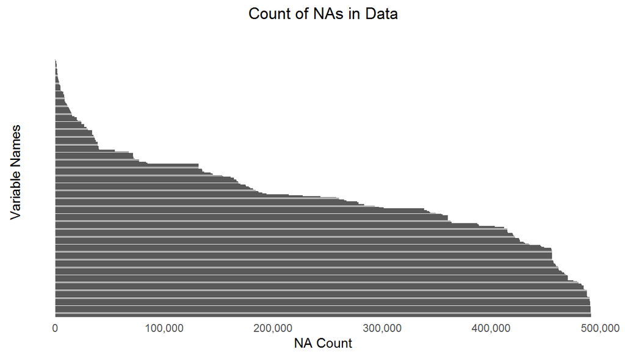

```r
library(ggplot2)
library(scales)
countNAs <- apply(modData, 2, function(x) sum(is.na(x)))
countNAs_df <- as.data.frame(countNAs)#change to data frame
countNAs_df$cat <- row.names(countNAs_df)#copy row names to its own column)variable)
options(scipen=999)#prevents scientific notation
countNAs_df$percentNA <- format(countNAs_df$countNAs/nrow(modData), digits = 2)
countNAs_df$percentNA <- as.numeric(countNAs_df$percentNA)

plot5 <- ggplot(countNAs_df, aes(x = reorder(cat, -countNAs), y = countNAs),
                ylab("NA Count"), xlab("Variable Name")) +
  geom_bar(stat = "identity") +
  theme(axis.ticks = element_blank(), axis.text.y = element_blank()) +
  scale_y_continuous(labels = comma) +
  xlab("Variable Names") + ylab("NA Count") + ggtitle("Count of NAs in Data") + coord_flip()
plot5
```

The plot was intentionally designed not to display the variables on the y axis - there are too many of them. The plot does tell me what I want to know - many of the variables have very high numbers of NAs. We need to remove these variables. Too many NAs may provide unreliable associations.

```r
#Will set a varible to serve as a cuttoff of data based on the pecent of NAs
cutoffValue = as.numeric(.3)
varibleNames <-countNAs_df %>% filter(percentNA<cutoffValue)
```

Here is a sampling of the variables that have less than 30% NAs. There several variables of no interest.

Here is an example of a variable that is not interesting: **X_misvegn**

```r
unique(modData$X_misvegn)
```

```
## [1] 1 missing response             No missing vegetable responses
## [3] 4 missing responses            2 missing responses
## [5] 3 missing responses            <NA>
## 5 Levels: No missing vegetable responses ... 4 missing responses
```

A full list of the variables is presented in the appendix.

- addepev2 - Ever Told You Had A Depressive Disorder
- checkup1 - Length Of Time Since Last Routine Checkup
- children - Number Of Children In Household
- ctelenum - Correct Telephone Number?
- cvdcrhd4 - Ever Diagnosed With Angina Or Coronary Heart Disease
- cvdstrk3 - Ever Diagnosed With A Stroke
- diabage2 - Age When Told Diabetic
- dispcode - Final Disposition
- dlyother - Delayed Getting Medical Care Other Response
- educa - Education Level
- employ1 - Employment Status
- fc60_ - Estimated Functional Capacity
- fmonth - File Month
- genhlth - General Health
- havarth3 - Told Have Arthritis
- hlthcvrg - Health Insurance Coverage
- iday - Interview Day
- imonth - Interview Month
- internet - Internet Use In The Past 30 Days?
- qstver - Questionnaire Version Identifier
- seqno - Annual Sequence Number
- sex - Respondents Sex
- X_fruitex - Fruit Exclusion From Analyses
- X_hispanc - Hispanic, Latino/A, Or Spanish Origin Calculated Variable
- X_imprace - Imputed Race/Ethnicity Value
- X_llcpwt - Final Weight: Land-Line And Cell-Phone Data
- X_llcpwt2 - Truncated Design Weight Used In Adult Combined Land Line And Cell Phone Raking
- X_wt2rake - Design Weight Used In Raking

```r
#Lets save the varible names to use them to filter only the data we want

variablesIwant <- c("X_state","is_State", "addepev2", "alcday5", "asthma3", "beanday_", "bloodcho", "bphigh4", "chccopd1", "chckidny", "chcocncr", "chcscncr", "checkup1", "children","cholchk",  "cvdcrhd4", "cvdinfr4", "cvdstrk3", "decide", "diffalon","diffdres", "diffwalk", "doctdiab", "drnkany5", "drocdy3_", "educa", "employ1", "exerany2", "fc60_", "flushot6", "fruit1", "fruitju1", "frutda1_", "ftjuda1_", "fvbeans", "fvgreen", "fvorang", "genhlth", "grenday_", "havarth3", "height3","hivtst6", "hlthcvrg", "hlthpln1","income2", "is_State", "internet", "iyear", "marital", "medbills", "medcost", "medscost", "menthlth", "numadult", "nummen", "numwomen", "orngday_", "pa1vigm_", "persdoc2", "physhlth", "pneuvac3", "pvtresd1", "qlactlm2", "qstlang", "renthom1", "seatbelt", "sex", "sleptim1", "smoke100", "tetanus", "toldhi2", "useequip", "usenow3", "vegeda1_", "vegetab1", "veteran3", "weight2", "X_age80", "X_aidtst3", "X_asthms1", "X_casthm1", "X_chldcnt", "X_cholchk", "X_drdxar1", "X_drnkdy4", "X_drnkmo4",  "X_educag", "X_frtlt1", "X_frutsum", "X_imprace", "X_incomg", "X_lmtact1","X_lmtscl1", "X_lmtwrk1", "X_ltasth1", "X_misfrtn", "X_misvegn", "X_pa150r2", "X_pa30021", "X_pa300r2", "X_pacat1", "X_pastae1", "X_rfbing5",  "X_rfbmi5", "X_rfchol", "X_rfdrhv4", "X_rfhlth", "X_rfhype5", "X_rfseat2", "X_rfseat3", "X_rfsmok3", "X_smoker3", "X_totinda", "X_veg23", "X_vegesum", "X_veglt1")

workingData <- select(modData,one_of(variablesIwant))#new option for me in dplyr - useful
```

We have the varibles that we want but the names of the variables can be cryptic. Let’s rename the variables to something that is easier to interpret.

```r
#Rename with dplyr
workingData <- rename(workingData,
                  US_State = X_state,
                  Is_US_State = is_State,
                  Year = iyear,
                  AlcoholDays_Past_30 = alcday5,
                  Heavy_Alcohol_Calc = X_rfdrhv4,
                  Beans_Day = beanday_,
                  Cholesteral_Check = bloodcho,
                  Last_Cholesteral_Chk = cholchk,
                  Number_Adults = numadult,
                  Number_Men = nummen,
                  Number_Women = numwomen,
                  General_Health = genhlth,
                  Phys_Not_OK =  physhlth,
                  Mental_Not_OK = menthlth,
                  Sleep_Hrs = sleptim1,
                  Depress_Disorder = addepev2,
                  Education = educa,
                  Weight = weight2,
                  Exercise_Past30 = exerany2,
                  Asthma = asthma3,
                  High_BP = bphigh4,
                  COPD = chccopd1,
                  Kidney_Disease = chckidny,
                  Other_Cancer = chcocncr,
                  Skin_Cancer = chcscncr,
                  Last_Checkup = checkup1,
                  Concentration = decide,
                  No_Children = children,
                  Heart_Disease = cvdcrhd4,
                  Heart_Attack = cvdinfr4,
                  Stroke = cvdstrk3,
                  Difficulty_Errands = diffalon,
                  Difficult_Dressing = diffdres,
                  Difficult_Walk = diffwalk,
                  Alcohol_Past_30 = drnkany5,
                  Computed_Drinks_Day = drocdy3_,
                  Doc_Visits_Diabetes = doctdiab,
                  Employment = employ1,
                  Functional_Cap = fc60_,
                  Arthritis = havarth3,
                  Flu_Shot_12M = flushot6,
                  Times_Eat_Fruit = fruit1,
                  Drink_Fruit_Juice = fruitju1,
                  Computed_Fruit_Day = frutda1_,
                  Fruit_Juice_Times_Day = ftjuda1_,
                  Times_EatBeans = fvbeans,
                  Times_Eat_Greens = fvgreen,
                  Times_Eat_Orange = fvorang,
                  Computed_OrangePer_Day = orngday_,
                  Computed_GreensIn_Day = grenday_,
                  Height = height3,
                  HIV_Tested = hivtst6,
                  Health_Ins = hlthcvrg,
                  Any_Health_Cov = hlthpln1,
                  Income = income2,
                  Internet_Past_30 = internet,
                  Marital_Status = marital,
                  Have_Med_Bills =  medbills,
                  Dr_Cost_Too_Much = medcost,
                  Meds_Too_Expensive = medscost,
                  Vigorous_Activity = pa1vigm_,
                  Multiple_Docs = persdoc2,
                  Pneumonioa_Ever =  pneuvac3,
                  Private_Home = pvtresd1,
                  Activity_Lim_dBy_Health = qlactlm2,
                  Language_ID = qstlang,
                  Own_Rent  = renthom1,
                  Freq_Use_Seatbelt = seatbelt,
                  Sex = sex,
                  Smoke_100 = smoke100,
                  Tentanus_2005 = tetanus,
                  Told_Hi_Cholesterol = toldhi2,
                  Health_Sp_Equip = useequip,
                  Smokeless_Tabacco = usenow3,
                  Computed_Veg_Per_Day = vegeda1_,
                  Verteran = veteran3,
                  Weight = weight2,
                  Age_Group_80 = X_age80,
                  Asthma_Status = X_asthms1,
                  Diagnosed_Arthritis = X_drdxar1,
                  Computed_Drinks_Per_Day = X_drnkdy4,
                  Drinks_Per_Month = X_drnkmo4,
                  Computed_Educ = X_educag,
                  Imputed_Ethnicity = X_imprace,
                  Adults_Good_Health = X_rfhlth,
                  AIDS_Tested = X_aidtst3,
                  Asthma_Calc_Variable = X_casthm1,
                  Children_Calc = X_chldcnt,
                  Cholesterol_Calc = X_cholchk,
                  Fruit_1orMore_Day = X_frtlt1,
                  Fruit_Total_Day = X_frutsum,
                  Income_Calc = X_incomg,
                  Limited_Usual_Act = X_lmtact1,
                  Limited_Social_Act = X_lmtscl1,
                  Limited_Work_Act = X_lmtwrk1)
```

I wonder how many records exist for each state or non-state. Also, which state has the most records and which one has the fewest?

```r
countByState <- workingData %>% group_by(US_State) %>% summarize(RecordCount = n())
range(countByState$RecordCount)
```

```
## [1]  1897 33668
```

```r
filter(countByState, RecordCount == 33668)
```

```
## Source: local data frame [1 x 2]
##
##   US_State RecordCount
##     (fctr)       (int)
## 1  Florida       33668
```

```r
filter(countByState, RecordCount == 1897)
```

```
## Source: local data frame [1 x 2]
##
##   US_State RecordCount
##     (fctr)       (int)
## 1     Guam        1897
```

```r
#Cleanup evironmnet vaibles no longer needed
rm(countNAs_df); rm(countNAs); rm(modData); rm(variablesIwant); rm(cutoffValue)
rm(varibleNames); rm(countByState)
```

## Research questions

The Project requires that the research questions satisfy the following:

Come up with at least three research questions that you want to answer using these data. You should phrase your research questions in a way that matches up with the scope of inference your data set allows for.

- Make sure that at least two of these questions involve at least three variables. You are welcomed to create new variables based on existing ones.
- With each question include a brief discussion (1-2 sentences) as to why this question is of interest to you and/or your audience.*

The questions I address below are of interest only after reviewing the data available in the working data set. These are curious questions, not serious analytic ones. However, the questions meet the requirements. I hope you will find them interesting too.

### Research Quesion 1

> Do people that use the interenet drink more thna those that do not use the Internet?

From the working data set, let’s identify the varaibles we might need:

| My Variable Name | Original Variable Name | Description |
| --- | --- | --- |
| AlcoholDays_Past_30 | alcday5 | Days In Past 30 Had Alcoholic Beverage |
| Alcohol_Past_30 | drnkany5 | Drink Any Alcoholic Beverages In Past 30 Days |
| Computed_Drinks_Day | drocdy3_ | Computed Drink-Occasions-Per-Day |
| Number_Men | nummen | Number Of Adult Men In Household |
| Number_Women | numwomen | Number Of Adult Women In Household |
| Children_Calc | X_chldcnt | Computed Number Of Children In Household |
| No_Children | children | Number Of Children In Household |
| Internet_Past_30 | internet | Internet Use In The Past 30 Days? |
| Heavy_Alcohol_Calc | X_rfdrhv4 | Heavy Alcohol Consumption Calculated Variable |
| Is_US_State |  |  |

### Research Quesion 2

> Do people that eat lots of fruits and vegetables more active than those that do not eat these healthy foods?

### Research Quesion 3

> Are people less prone to depression or anxiety if they exercise?

# Appendix

## Varibles with <30% NAs:

- addepev2 - Ever Told You Had A Depressive Disorder
- alcday5 - Days In Past 30 Had Alcoholic Beverage
- asthma3 - Ever Told Had Asthma
- beanday_ - Computed Bean Intake In Times Per Day
- blind - Blind Or Difficulty Seeing
- bloodcho - Ever Had Blood Cholesterol Checked
- bphigh4 - Ever Told Blood Pressure High
- cellfon3 - cellfon3
- chccopd1 - (Ever Told) You Have (Copd) Chronic Obstructive Pulmonary Disease, Emphysema Or
- chckidny - (Ever Told) You Have Kidney Disease?
- chcocncr - (Ever Told) You Had Any Other Types Of Cancer?
- chcscncr - (Ever Told) You Had Skin Cancer?
- checkup1 - Length Of Time Since Last Routine Checkup
- children - Number Of Children In Household
- cholchk - How Long Since Cholesterol Checked
- cpdemo1 - Do You Have A Cell Phone For Personal Use?
- ctelenum - Cell number
- cvdcrhd4 - Ever Diagnosed With Angina Or Coronary Heart Disease
- cvdinfr4 - Ever Diagnosed With Heart Attack
- cvdstrk3 - Ever Diagnosed With A Stroke
- decide - Difficulty Concentrating Or Remembering
- delaymed - Delayed Getting Medical Care
- diabage2 - Age When Told Diabetic
- diabete3 - (Ever Told) You Have Diabetes
- diffalon - Difficulty Doing Errands Alone
- diffdres - Difficulty Dressing Or Bathing
- diffwalk - Difficulty Walking Or Climbing Stairs
- dispcode - Final Disposition
- dlyother - Delayed Getting Medical Care Other Response
- doctdiab - Times Seen Health Professional For Diabetes
- drnkany5 - Drink Any Alcoholic Beverages In Past 30 Days
- drocdy3_ - Computed Drink-Occasions-Per-Day
- educa - Education Level
- employ1 - Employment Status
- exerany2 - Exercise In Past 30 Days
- fc60_ - Estimated Functional Capacity
- flushot6 - Adult Flu Shot/Spray Past 12 Mos
- fmonth - File Month
- fruit1 - How Many Times Did You Eat Fruit?
- fruitju1 - How Many Times Did You Drink 100 Percent Pure Fruit Juices?
- frutda1_ - Computed Fruit Intake In Times Per Day
- ftjuda1_ - Computed Fruit Juice Intake In Times Per Day
- fvbeans - How Many Times Did You Eat Beans Or Lentils?
- fvgreen - How Many Times Did You Eat Dark Green Vegetables?
- fvorang - How Many Times Did You Eat Orange-Colored Vegetables?
- genhlth - General Health
- grenday_ - Computed Dark Green Vegetable Intake In Times Per Day
- havarth3 - Told Have Arthritis
- height3 - Reported Height In Feet And Inches
- hivtst6 - Ever Tested HIV
- hlthcvrg - Health Insurance Coverage
- hlthpln1 - Have Any Health Care Coverage
- htin4 - Height in in
- htm4 - height in m
- idate - Interview date
- iday - Interview Day
- imonth - Interview month
- income2 - Income level
- internet - Internet Use In The Past 30 Days?
- is_State - Is the location a US State
- iyear - Interview year
- marital - Marital Status
- maxvo2_ - Estimated Age-Gender Specific Maximum Oxygen Consumption
- medbills - Currently Have Medical Bills
- medcost - Could Not See Dr. Because Of Cost
- medscost - Could Not Get Medicine Due To Cost
- menthlth - Number Of Days Mental Health Not Good
- mscode - Metro status code
- numadult - Number Of Adults In Household
- numhhol2 - Household Telephones
- nummen - Number Of Adult Men In Household
- numwomen - Number Of Adult Women In Household
- orngday_ - Computed Orange-Colored Vegetable Intake In Times Per Day
- pa1vigm_ - Minutes Of Total Vigorous Physical Activity Per Week
- pamiss1_ - Missing Physical Activity Data
- persdoc2 - Multiple Health Care Professionals
- physhlth - Number Of Days Physical Health Not Good
- pneuvac3 - Pneumonia Shot Ever
- pvtresd1 - Private Residence?
- qlactlm2 - Activity Limitation Due To Health Problems
- qstlang - Language Identifier
- qstver - Questionnaire Version Identifier
- renthom1 - Own Or Rent Home
- seatbelt - How Often Use Seatbelts In Car?
- seqno - Annual Sequence Number
- sex - Respondents Sex
- sleptim1 - How Much Time Do You Sleep
- smoke100 - Smoked At Least 100 Cigarettes
- stateres - Resident Of State
- strength - How Many Times Did You Do Physical Activities Or Exercises To Strengthen Your Mu
- strfreq_ - Strength Activity Frequency Per Week
- tetanus - Received Tetanus Shot Since 2005?
- toldhi2 - Ever Told Blood Cholesterol High
- useequip - Health Problems Requiring Special Equipment
- usenow3 - Use Of Smokeless Tobacco Products
- vegeda1_ - Computed Vegetable Intake In Times Per Day
- vegetab1 - How Many Times Did You Eat Other Vegetables?
- veteran3 - Are you a verteran?
- weight2 - Reported Weight In Pounds
- wtkg3 - wt kg
- X_age_g - Imputed Age In Six Groups
- X_age65yr - Reported Age In Two Age Groups Calculated Variable
- X_age80 - Imputed Age Value Collapsed Above 80
- X_ageg5yr - Reported Age In Five-Year Age Categories Calculated Variable
- X_aidtst3 - Ever Been Tested For HIV Calculated Variable
- X_asthms1 - Computed Asthma Status
- X_bmi5 - Computed Body Mass Index
- X_bmi5cat - Computed Body Mass Index Categories
- X_casthm1 - Current Asthma Calculated Variable
- X_chldcnt - Computed Number Of Children In Household
- X_cholchk - Cholesterol Checked Calculated Variable
- X_drdxar1 - Respondents Diagnosed With Arthritis
- X_drnkdy4 - Computed Number Of Drinks Of Alcohol Beverages Per Day
- X_drnkmo4 - Computed Total Number Drinks A Month
- X_dualuse - Dual Phone Use Categories
- X_educag - Computed Level Of Education Completed Categories
- X_frt16 - Reported Consuming Fruit >16/Day
- X_frtlt1 - Consume Fruit 1 Or More Times Per Day
- X_frtresp - Missing Any Fruit Responses
- X_fruitex - Fruit Exclusion From Analyses
- X_frutsum - Total Fruits Consumed Per Day
- X_hispanc - Hispanic, Latino/A, Or Spanish Origin Calculated Variable
- X_impnph - Imputed Number Of Phones
- X_imprace - Imputed Race/Ethnicity Value
- X_incomg - Computed Income Categories
- X_llcpwt - Final Weight: Land-Line And Cell-Phone Data
- X_llcpwt2 - Truncated Design Weight Used In Adult Combined Land Line And Cell Phone Raking
- X_lmtact1 - Limited Usual Activities
- X_lmtscl1 - Limited Social Activities
- X_lmtwrk1 - Limited Work Activities
- X_ltasth1 - Lifetime Asthma Calculated Variable
- X_misfrtn - The Number Of Missing Fruit Responses
- X_misvegn - The Number Of Missing Vegetable Responses
- X_mrace1 - Calculated Non-Hispanic Race Including Multiracial
- X_pa150r2 - 150 Minute Physical Activity Calculated Variable
- X_pa30021 - 300 Minute Physical Activity 2-Level Calculated Variable
- X_pa300r2 - 300 Minute Physical Activity Calculated Variable
- X_pacat1 - Physical Activity Categories
- X_paindx1 - Physical Activity Index
- X_parec1 - Aerobic And Strengthening Guideline
- X_pastae1 - Aerobic And Strengthening (2-Level)
- X_pastrng - Muscle Strengthening Recommendation
- X_prace1 - Computed Preferred Race
- X_psu - Primary Sampling Unit
- X_race - Computed Race-Ethnicity Grouping
- X_race_g1 - Computed Race Groups Used For Internet Prevalence Tables
- X_raceg21 - Computed Non-Hispanic Whites/All Others Race Categories Race/Ethnic Group Codes
- X_racegr3 - Computed Five Level Race/Ethnicity Category.
- X_rawrake - Raw Weighting Factor Used In Raking
- X_rfbing5 - Binge Drinking Calculated Variable
- X_rfbmi5 - Overweight Or Obese Calculated Variable
- X_rfchol - High Cholesterol Calculated Variable
- X_rfdrhv4 - Heavy Alcohol Consumption Calculated Variable
- X_rfhlth - Adults With Good Or Better Health
- X_rfhype5 - High Blood Pressure Calculated Variable
- X_rfseat2 - Always Or Nearly Always Wear Seat Belts
- X_rfseat3 - Always Wear Seat Belts
- X_rfsmok3 - Current Smoking Calculated Variable
- X_smoker3 - Computed Smoking Status
- X_state - State Name
- X_strwt - Stratum Weight
- X_ststr - Sample Design Stratification Variable
- X_totinda - Leisure Time Physical Activity Calculated Variable
- X_veg23 - Reported Consuming Vegetables >23/Day
- X_vegesum - Total Vegetables Consumed Per Day
- X_vegetex - Vegetable Exclusion From Analyses
- X_veglt1 - Consume Vegetables 1 Or More Times Per Day
- X_vegresp - Missing Any Vegetable Responses
- X_wt2rake - Design Weight Used In Raking